# Risk Factor Analysis

## Outcome Variable

**Outcome Variable:** wasted

## Predictor Variables

**Intervention Variable:** hfoodsec

**Adjustment Set:**

- arm
- sex
- W_mage
- meducyrs
- feducyrs
- hhwealth_quart
- vagbrth
- W_nrooms
- W_nchldlt5
- brthmon
- W_parity
- impfloor
- impsan
- safeh20
- delta_W_mage
- delta_meducyrs
- delta_feducyrs
- delta_hhwealth_quart
- delta_vagbrth
- delta_W_nrooms
- delta_W_nchldlt5
- delta_brthmon
- delta_W_parity
- delta_impfloor
- delta_impsan
- delta_safeh20

## Stratifying Variables

The analysis was stratified on these variable(s):

- agecat
- studyid
- country

## Data Summary

| agecat | studyid | country | hfoodsec | wasted | n_cell | n |
| --- | --- | --- | --- | --- | --- | --- |
| Birth | ki0047075b-MAL-ED | BANGLADESH | Food Secure | 0 | 125 | 178 |
| Birth | ki0047075b-MAL-ED | BANGLADESH | Food Secure | 1 | 26 | 178 |
| Birth | ki0047075b-MAL-ED | BANGLADESH | Mildly Food Insecure | 0 | 3 | 178 |
| Birth | ki0047075b-MAL-ED | BANGLADESH | Mildly Food Insecure | 1 | 0 | 178 |
| Birth | ki0047075b-MAL-ED | BANGLADESH | Food Insecure | 0 | 19 | 178 |
| Birth | ki0047075b-MAL-ED | BANGLADESH | Food Insecure | 1 | 5 | 178 |
| Birth | ki0047075b-MAL-ED | BRAZIL | Food Secure | 0 | 0 | 102 |
| Birth | ki0047075b-MAL-ED | BRAZIL | Food Secure | 1 | 0 | 102 |
| Birth | ki0047075b-MAL-ED | BRAZIL | Mildly Food Insecure | 0 | 11 | 102 |
| Birth | ki0047075b-MAL-ED | BRAZIL | Mildly Food Insecure | 1 | 0 | 102 |
| Birth | ki0047075b-MAL-ED | BRAZIL | Food Insecure | 0 | 87 | 102 |
| Birth | ki0047075b-MAL-ED | BRAZIL | Food Insecure | 1 | 4 | 102 |
| Birth | ki0047075b-MAL-ED | INDIA | Food Secure | 0 | 128 | 167 |
| Birth | ki0047075b-MAL-ED | INDIA | Food Secure | 1 | 23 | 167 |
| Birth | ki0047075b-MAL-ED | INDIA | Mildly Food Insecure | 0 | 1 | 167 |
| Birth | ki0047075b-MAL-ED | INDIA | Mildly Food Insecure | 1 | 1 | 167 |
| Birth | ki0047075b-MAL-ED | INDIA | Food Insecure | 0 | 10 | 167 |
| Birth | ki0047075b-MAL-ED | INDIA | Food Insecure | 1 | 4 | 167 |
| Birth | ki0047075b-MAL-ED | NEPAL | Food Secure | 0 | 63 | 96 |
| Birth | ki0047075b-MAL-ED | NEPAL | Food Secure | 1 | 12 | 96 |
| Birth | ki0047075b-MAL-ED | NEPAL | Mildly Food Insecure | 0 | 8 | 96 |
| Birth | ki0047075b-MAL-ED | NEPAL | Mildly Food Insecure | 1 | 1 | 96 |
| Birth | ki0047075b-MAL-ED | NEPAL | Food Insecure | 0 | 11 | 96 |
| Birth | ki0047075b-MAL-ED | NEPAL | Food Insecure | 1 | 1 | 96 |
| Birth | ki0047075b-MAL-ED | PERU | Food Secure | 0 | 25 | 105 |
| Birth | ki0047075b-MAL-ED | PERU | Food Secure | 1 | 1 | 105 |
| Birth | ki0047075b-MAL-ED | PERU | Mildly Food Insecure | 0 | 24 | 105 |
| Birth | ki0047075b-MAL-ED | PERU | Mildly Food Insecure | 1 | 0 | 105 |
| Birth | ki0047075b-MAL-ED | PERU | Food Insecure | 0 | 53 | 105 |
| Birth | ki0047075b-MAL-ED | PERU | Food Insecure | 1 | 2 | 105 |

[output cut: 162 more lines]

The following strata were considered:

- agecat: 24 months, studyid: ki0047075b-MAL-ED, country: BANGLADESH
- agecat: 24 months, studyid: ki0047075b-MAL-ED, country: BRAZIL
- agecat: 24 months, studyid: ki0047075b-MAL-ED, country: INDIA
- agecat: 24 months, studyid: ki0047075b-MAL-ED, country: NEPAL
- agecat: 24 months, studyid: ki0047075b-MAL-ED, country: PERU
- agecat: 24 months, studyid: ki0047075b-MAL-ED, country: SOUTH AFRICA
- agecat: 24 months, studyid: ki1017093-NIH-Birth, country: BANGLADESH
- agecat: 24 months, studyid: ki1017093c-NIH-Crypto, country: BANGLADESH
- agecat: 24 months, studyid: ki1113344-GMS-Nepal, country: NEPAL
- agecat: 24 months, studyid: kiGH5241-JiVitA-3, country: BANGLADESH
- agecat: 24 months, studyid: kiGH5241-JiVitA-4, country: BANGLADESH
- agecat: 6 months, studyid: ki0047075b-MAL-ED, country: BANGLADESH
- agecat: 6 months, studyid: ki0047075b-MAL-ED, country: BRAZIL
- agecat: 6 months, studyid: ki0047075b-MAL-ED, country: INDIA
- agecat: 6 months, studyid: ki0047075b-MAL-ED, country: NEPAL
- agecat: 6 months, studyid: ki0047075b-MAL-ED, country: PERU
- agecat: 6 months, studyid: ki0047075b-MAL-ED, country: SOUTH AFRICA
- agecat: 6 months, studyid: ki1017093-NIH-Birth, country: BANGLADESH
- agecat: 6 months, studyid: ki1017093c-NIH-Crypto, country: BANGLADESH
- agecat: 6 months, studyid: ki1113344-GMS-Nepal, country: NEPAL
- agecat: 6 months, studyid: kiGH5241-JiVitA-3, country: BANGLADESH
- agecat: 6 months, studyid: kiGH5241-JiVitA-4, country: BANGLADESH
- agecat: Birth, studyid: ki0047075b-MAL-ED, country: BANGLADESH
- agecat: Birth, studyid: ki0047075b-MAL-ED, country: BRAZIL
- agecat: Birth, studyid: ki0047075b-MAL-ED, country: INDIA
- agecat: Birth, studyid: ki0047075b-MAL-ED, country: NEPAL
- agecat: Birth, studyid: ki0047075b-MAL-ED, country: PERU
- agecat: Birth, studyid: ki0047075b-MAL-ED, country: SOUTH AFRICA
- agecat: Birth, studyid: ki1017093-NIH-Birth, country: BANGLADESH
- agecat: Birth, studyid: ki1017093c-NIH-Crypto, country: BANGLADESH
- agecat: Birth, studyid: kiGH5241-JiVitA-3, country: BANGLADESH
- agecat: Birth, studyid: kiGH5241-JiVitA-4, country: BANGLADESH

### Dropped Strata

Some strata were dropped due to rare outcomes:

- agecat: Birth, studyid: ki0047075b-MAL-ED, country: BANGLADESH
- agecat: Birth, studyid: ki0047075b-MAL-ED, country: BRAZIL
- agecat: Birth, studyid: ki0047075b-MAL-ED, country: INDIA
- agecat: Birth, studyid: ki0047075b-MAL-ED, country: NEPAL
- agecat: Birth, studyid: ki0047075b-MAL-ED, country: PERU
- agecat: Birth, studyid: ki0047075b-MAL-ED, country: SOUTH AFRICA
- agecat: Birth, studyid: ki1017093-NIH-Birth, country: BANGLADESH
- agecat: Birth, studyid: ki1017093c-NIH-Crypto, country: BANGLADESH
- agecat: 6 months, studyid: ki0047075b-MAL-ED, country: BANGLADESH
- agecat: 6 months, studyid: ki0047075b-MAL-ED, country: BRAZIL
- agecat: 6 months, studyid: ki0047075b-MAL-ED, country: INDIA
- agecat: 6 months, studyid: ki0047075b-MAL-ED, country: NEPAL
- agecat: 6 months, studyid: ki0047075b-MAL-ED, country: PERU
- agecat: 6 months, studyid: ki0047075b-MAL-ED, country: SOUTH AFRICA
- agecat: 6 months, studyid: ki1017093-NIH-Birth, country: BANGLADESH
- agecat: 6 months, studyid: ki1017093c-NIH-Crypto, country: BANGLADESH
- agecat: 6 months, studyid: ki1113344-GMS-Nepal, country: NEPAL
- agecat: 24 months, studyid: ki0047075b-MAL-ED, country: BANGLADESH
- agecat: 24 months, studyid: ki0047075b-MAL-ED, country: BRAZIL
- agecat: 24 months, studyid: ki0047075b-MAL-ED, country: INDIA
- agecat: 24 months, studyid: ki0047075b-MAL-ED, country: NEPAL
- agecat: 24 months, studyid: ki0047075b-MAL-ED, country: PERU
- agecat: 24 months, studyid: ki0047075b-MAL-ED, country: SOUTH AFRICA
- agecat: 24 months, studyid: ki1017093-NIH-Birth, country: BANGLADESH

## Methods Detail

We’re interested in the causal parameters $E[Y_a]$ for all values of $a \in \mathcal{A}$. These parameters represent the mean outcome if, possibly contrary to fact, we intervened to set all units to have $A=a$. Under the randomization and positivity assumptions, these are identified by the statistical parameters $\psi_a=E_W[E_{Y|A,W}(Y|A=a,W)]$. In addition, we’re interested in the mean of $Y$, $E[Y]$ under no intervention (the observed mean). We will estimate these parameters by using SuperLearner to fit the relevant likelihood factors – $E_{Y|A,W}(Y|A=a,W)$ and $p(A=a|W)$, and then updating our likelihood fit using a joint TMLE.

For unadjusted analyses ($W=\{\}$), initial likelihoods were estimated using Lrnr_glm to estimate the simple $E(Y|A)$ and Lrnr_mean to estimate $p(A)$. For adjusted analyses, a small library containing Lrnr_glmnet, Lrnr_xgboost, and Lrnr_mean was used.

Having estimated these parameters, we will then use the delta method to estimate relative risks and attributable risks relative to a prespecified baseline level of $A$.

# Results Detail

## Results Plots

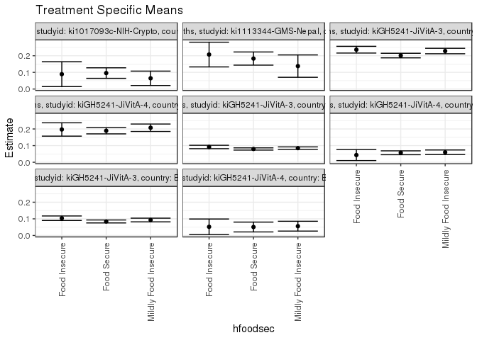

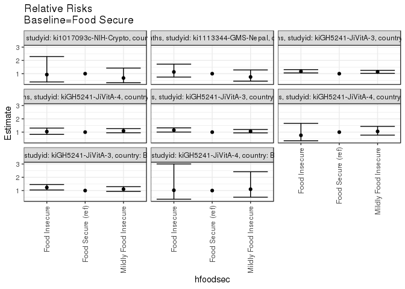

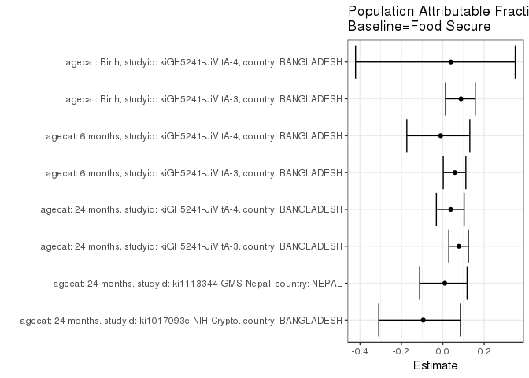

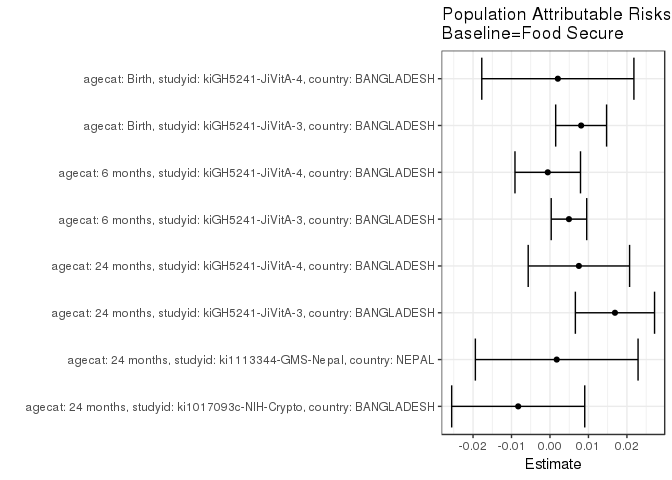

## Results Table

### Parameter: TSM

| agecat | studyid | country | intervention_level | baseline_level | estimate | ci_lower | ci_upper |
| --- | --- | --- | --- | --- | --- | --- | --- |
| Birth | kiGH5241-JiVitA-3 | BANGLADESH | Food Secure | NA | 0.0842337 | 0.0753953 | 0.0930721 |
| Birth | kiGH5241-JiVitA-3 | BANGLADESH | Mildly Food Insecure | NA | 0.0930198 | 0.0819736 | 0.1040660 |
| Birth | kiGH5241-JiVitA-3 | BANGLADESH | Food Insecure | NA | 0.1037235 | 0.0901923 | 0.1172547 |
| Birth | kiGH5241-JiVitA-4 | BANGLADESH | Food Secure | NA | 0.0508982 | 0.0212854 | 0.0805110 |
| Birth | kiGH5241-JiVitA-4 | BANGLADESH | Mildly Food Insecure | NA | 0.0560000 | 0.0265243 | 0.0854757 |
| Birth | kiGH5241-JiVitA-4 | BANGLADESH | Food Insecure | NA | 0.0520833 | 0.0052358 | 0.0989309 |
| 6 months | kiGH5241-JiVitA-3 | BANGLADESH | Food Secure | NA | 0.0797959 | 0.0731332 | 0.0864585 |
| 6 months | kiGH5241-JiVitA-3 | BANGLADESH | Mildly Food Insecure | NA | 0.0847878 | 0.0773221 | 0.0922534 |
| 6 months | kiGH5241-JiVitA-3 | BANGLADESH | Food Insecure | NA | 0.0917996 | 0.0815359 | 0.1020632 |
| 6 months | kiGH5241-JiVitA-4 | BANGLADESH | Food Secure | NA | 0.0568478 | 0.0452037 | 0.0684919 |
| 6 months | kiGH5241-JiVitA-4 | BANGLADESH | Mildly Food Insecure | NA | 0.0598811 | 0.0460061 | 0.0737561 |
| 6 months | kiGH5241-JiVitA-4 | BANGLADESH | Food Insecure | NA | 0.0432730 | 0.0103825 | 0.0761634 |
| 24 months | ki1017093c-NIH-Crypto | BANGLADESH | Food Secure | NA | 0.0958084 | 0.0642126 | 0.1274042 |
| 24 months | ki1017093c-NIH-Crypto | BANGLADESH | Mildly Food Insecure | NA | 0.0645161 | 0.0212336 | 0.1077986 |
| 24 months | ki1017093c-NIH-Crypto | BANGLADESH | Food Insecure | NA | 0.0892857 | 0.0145275 | 0.1640439 |
| 24 months | ki1113344-GMS-Nepal | NEPAL | Food Secure | NA | 0.1830556 | 0.1435411 | 0.2225701 |
| 24 months | ki1113344-GMS-Nepal | NEPAL | Mildly Food Insecure | NA | 0.1376411 | 0.0703777 | 0.2049044 |
| 24 months | ki1113344-GMS-Nepal | NEPAL | Food Insecure | NA | 0.2071304 | 0.1328236 | 0.2814371 |
| 24 months | kiGH5241-JiVitA-3 | BANGLADESH | Food Secure | NA | 0.2010593 | 0.1872751 | 0.2148435 |
| 24 months | kiGH5241-JiVitA-3 | BANGLADESH | Mildly Food Insecure | NA | 0.2282903 | 0.2119073 | 0.2446733 |
| 24 months | kiGH5241-JiVitA-3 | BANGLADESH | Food Insecure | NA | 0.2363124 | 0.2160528 | 0.2565720 |
| 24 months | kiGH5241-JiVitA-4 | BANGLADESH | Food Secure | NA | 0.1891927 | 0.1705442 | 0.2078411 |
| 24 months | kiGH5241-JiVitA-4 | BANGLADESH | Mildly Food Insecure | NA | 0.2073675 | 0.1850834 | 0.2296516 |
| 24 months | kiGH5241-JiVitA-4 | BANGLADESH | Food Insecure | NA | 0.1969490 | 0.1568659 | 0.2370320 |

### Parameter: E(Y)

| agecat | studyid | country | intervention_level | baseline_level | estimate | ci_lower | ci_upper |
| --- | --- | --- | --- | --- | --- | --- | --- |
| Birth | kiGH5241-JiVitA-3 | BANGLADESH | NA | NA | 0.0923316 | 0.0861106 | 0.0985527 |
| Birth | kiGH5241-JiVitA-4 | BANGLADESH | NA | NA | 0.0529412 | 0.0337951 | 0.0720872 |
| 6 months | kiGH5241-JiVitA-3 | BANGLADESH | NA | NA | 0.0847296 | 0.0799320 | 0.0895271 |
| 6 months | kiGH5241-JiVitA-4 | BANGLADESH | NA | NA | 0.0562660 | 0.0473007 | 0.0652313 |
| 24 months | ki1017093c-NIH-Crypto | BANGLADESH | NA | NA | 0.0875486 | 0.0630907 | 0.1120065 |
| 24 months | ki1113344-GMS-Nepal | NEPAL | NA | NA | 0.1848049 | 0.1502971 | 0.2193127 |
| 24 months | kiGH5241-JiVitA-3 | BANGLADESH | NA | NA | 0.2179495 | 0.2080242 | 0.2278748 |
| 24 months | kiGH5241-JiVitA-4 | BANGLADESH | NA | NA | 0.1967070 | 0.1831292 | 0.2102848 |

### Parameter: RR

| agecat | studyid | country | intervention_level | baseline_level | estimate | ci_lower | ci_upper |
| --- | --- | --- | --- | --- | --- | --- | --- |
| Birth | kiGH5241-JiVitA-3 | BANGLADESH | Food Secure | Food Secure | 1.0000000 | 1.0000000 | 1.000000 |
| Birth | kiGH5241-JiVitA-3 | BANGLADESH | Mildly Food Insecure | Food Secure | 1.1043061 | 0.9408041 | 1.296223 |
| Birth | kiGH5241-JiVitA-3 | BANGLADESH | Food Insecure | Food Secure | 1.2313781 | 1.0437822 | 1.452690 |
| Birth | kiGH5241-JiVitA-4 | BANGLADESH | Food Secure | Food Secure | 1.0000000 | 1.0000000 | 1.000000 |
| Birth | kiGH5241-JiVitA-4 | BANGLADESH | Mildly Food Insecure | Food Secure | 1.1002353 | 0.5007140 | 2.417583 |
| Birth | kiGH5241-JiVitA-4 | BANGLADESH | Food Insecure | Food Secure | 1.0232843 | 0.3487644 | 3.002344 |
| 6 months | kiGH5241-JiVitA-3 | BANGLADESH | Food Secure | Food Secure | 1.0000000 | 1.0000000 | 1.000000 |
| 6 months | kiGH5241-JiVitA-3 | BANGLADESH | Mildly Food Insecure | Food Secure | 1.0625587 | 0.9429269 | 1.197369 |
| 6 months | kiGH5241-JiVitA-3 | BANGLADESH | Food Insecure | Food Secure | 1.1504303 | 1.0031840 | 1.319289 |
| 6 months | kiGH5241-JiVitA-4 | BANGLADESH | Food Secure | Food Secure | 1.0000000 | 1.0000000 | 1.000000 |
| 6 months | kiGH5241-JiVitA-4 | BANGLADESH | Mildly Food Insecure | Food Secure | 1.0533577 | 0.7744322 | 1.432743 |
| 6 months | kiGH5241-JiVitA-4 | BANGLADESH | Food Insecure | Food Secure | 0.7612071 | 0.3490941 | 1.659828 |
| 24 months | ki1017093c-NIH-Crypto | BANGLADESH | Food Secure | Food Secure | 1.0000000 | 1.0000000 | 1.000000 |
| 24 months | ki1017093c-NIH-Crypto | BANGLADESH | Mildly Food Insecure | Food Secure | 0.6733871 | 0.3188651 | 1.422075 |
| 24 months | ki1017093c-NIH-Crypto | BANGLADESH | Food Insecure | Food Secure | 0.9319196 | 0.3789294 | 2.291916 |
| 24 months | ki1113344-GMS-Nepal | NEPAL | Food Secure | Food Secure | 1.0000000 | 1.0000000 | 1.000000 |
| 24 months | ki1113344-GMS-Nepal | NEPAL | Mildly Food Insecure | Food Secure | 0.7519083 | 0.4406096 | 1.283145 |
| 24 months | ki1113344-GMS-Nepal | NEPAL | Food Insecure | Food Secure | 1.1315158 | 0.7444049 | 1.719935 |
| 24 months | kiGH5241-JiVitA-3 | BANGLADESH | Food Secure | Food Secure | 1.0000000 | 1.0000000 | 1.000000 |
| 24 months | kiGH5241-JiVitA-3 | BANGLADESH | Mildly Food Insecure | Food Secure | 1.1354375 | 1.0286870 | 1.253266 |
| 24 months | kiGH5241-JiVitA-3 | BANGLADESH | Food Insecure | Food Secure | 1.1753366 | 1.0572907 | 1.306562 |
| 24 months | kiGH5241-JiVitA-4 | BANGLADESH | Food Secure | Food Secure | 1.0000000 | 1.0000000 | 1.000000 |
| 24 months | kiGH5241-JiVitA-4 | BANGLADESH | Mildly Food Insecure | Food Secure | 1.0960652 | 0.9485600 | 1.266508 |
| 24 months | kiGH5241-JiVitA-4 | BANGLADESH | Food Insecure | Food Secure | 1.0409968 | 0.8299825 | 1.305659 |

### Parameter: PAR

| agecat | studyid | country | intervention_level | baseline_level | estimate | ci_lower | ci_upper |
| --- | --- | --- | --- | --- | --- | --- | --- |
| Birth | kiGH5241-JiVitA-3 | BANGLADESH | Food Secure | NA | 0.0080979 | 0.0014822 | 0.0147136 |
| Birth | kiGH5241-JiVitA-4 | BANGLADESH | Food Secure | NA | 0.0020430 | -0.0177303 | 0.0218162 |
| 6 months | kiGH5241-JiVitA-3 | BANGLADESH | Food Secure | NA | 0.0049337 | 0.0003180 | 0.0095494 |
| 6 months | kiGH5241-JiVitA-4 | BANGLADESH | Food Secure | NA | -0.0005818 | -0.0090992 | 0.0079356 |
| 24 months | ki1017093c-NIH-Crypto | BANGLADESH | Food Secure | NA | -0.0082597 | -0.0255539 | 0.0090344 |
| 24 months | ki1113344-GMS-Nepal | NEPAL | Food Secure | NA | 0.0017493 | -0.0193981 | 0.0228967 |
| 24 months | kiGH5241-JiVitA-3 | BANGLADESH | Food Secure | NA | 0.0168902 | 0.0065980 | 0.0271824 |
| 24 months | kiGH5241-JiVitA-4 | BANGLADESH | Food Secure | NA | 0.0075143 | -0.0056637 | 0.0206924 |

### Parameter: PAF

| agecat | studyid | country | intervention_level | baseline_level | estimate | ci_lower | ci_upper |
| --- | --- | --- | --- | --- | --- | --- | --- |
| Birth | kiGH5241-JiVitA-3 | BANGLADESH | Food Secure | NA | 0.0877048 | 0.0132389 | 0.1565511 |
| Birth | kiGH5241-JiVitA-4 | BANGLADESH | Food Secure | NA | 0.0385895 | -0.4214583 | 0.3497451 |
| 6 months | kiGH5241-JiVitA-3 | BANGLADESH | Food Secure | NA | 0.0582288 | 0.0020359 | 0.1112577 |
| 6 months | kiGH5241-JiVitA-4 | BANGLADESH | Food Secure | NA | -0.0103405 | -0.1738736 | 0.1304107 |
| 24 months | ki1017093c-NIH-Crypto | BANGLADESH | Food Secure | NA | -0.0943446 | -0.3091652 | 0.0852260 |
| 24 months | ki1113344-GMS-Nepal | NEPAL | Food Secure | NA | 0.0094656 | -0.1117485 | 0.1174637 |
| 24 months | kiGH5241-JiVitA-3 | BANGLADESH | Food Secure | NA | 0.0774959 | 0.0291675 | 0.1234185 |
| 24 months | kiGH5241-JiVitA-4 | BANGLADESH | Food Secure | NA | 0.0382007 | -0.0311556 | 0.1028920 |